# Análisis Comparativo de Indicadores: Argentina-Chile

## Brechas estandarizadas

Bajo esta transformación, las brechas estandarizadas se interpretan como desviaciones respecto del promedio del indicador:

```
Z_(i,c,t)>0: integración relativa de la población migrante superior al promedio del indicador

Z_(i,c,t)<0: integración relativa inferior al promedio

Z_(i,c,t)=0: brecha equivalente al promedio del indicador
```

La magnitud de Z_(i,c,t)indica cuántos desvíos estándar se encuentra la brecha observada respecto de la media.

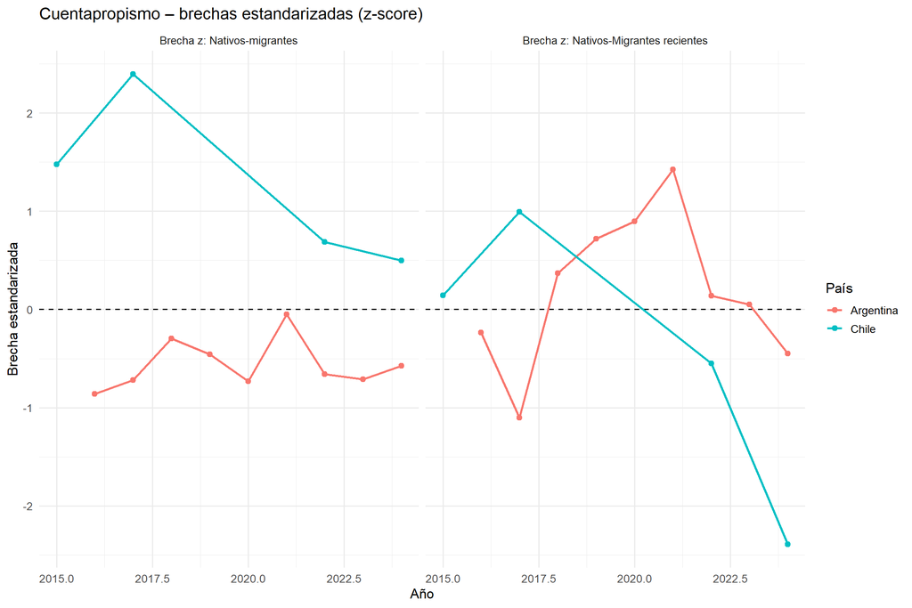

## Distribución de brechas

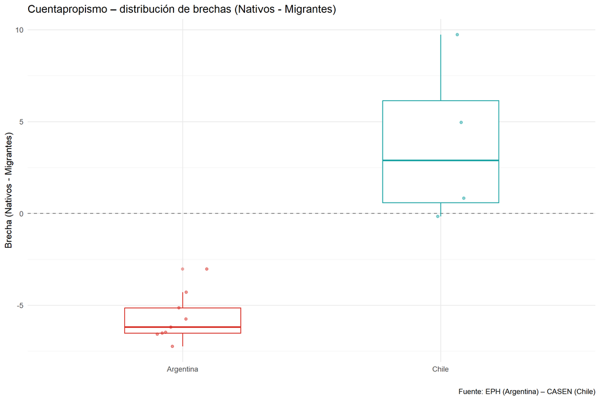

## Distribucion de brechas - grafico 2

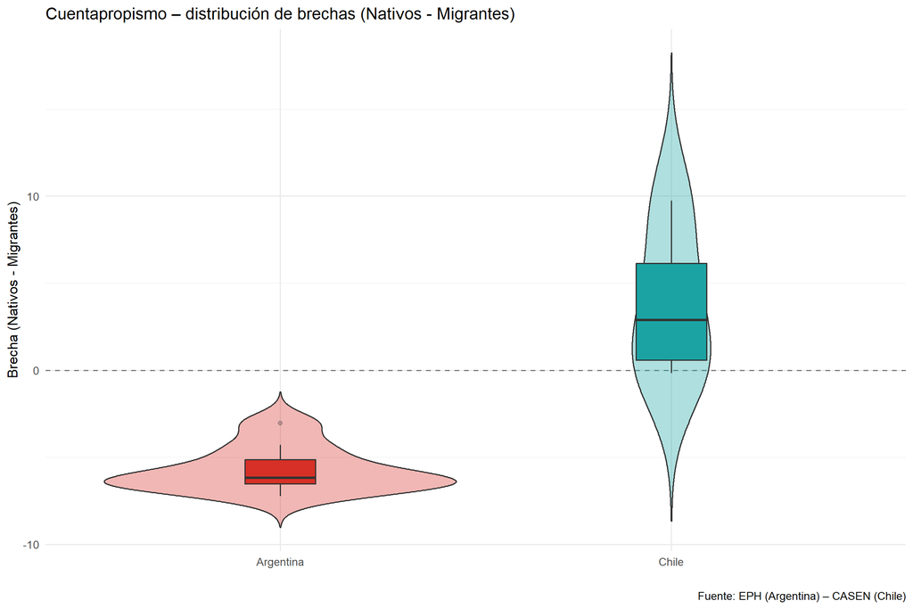

## distribucion de brechas migracion general y reciente en Argentina

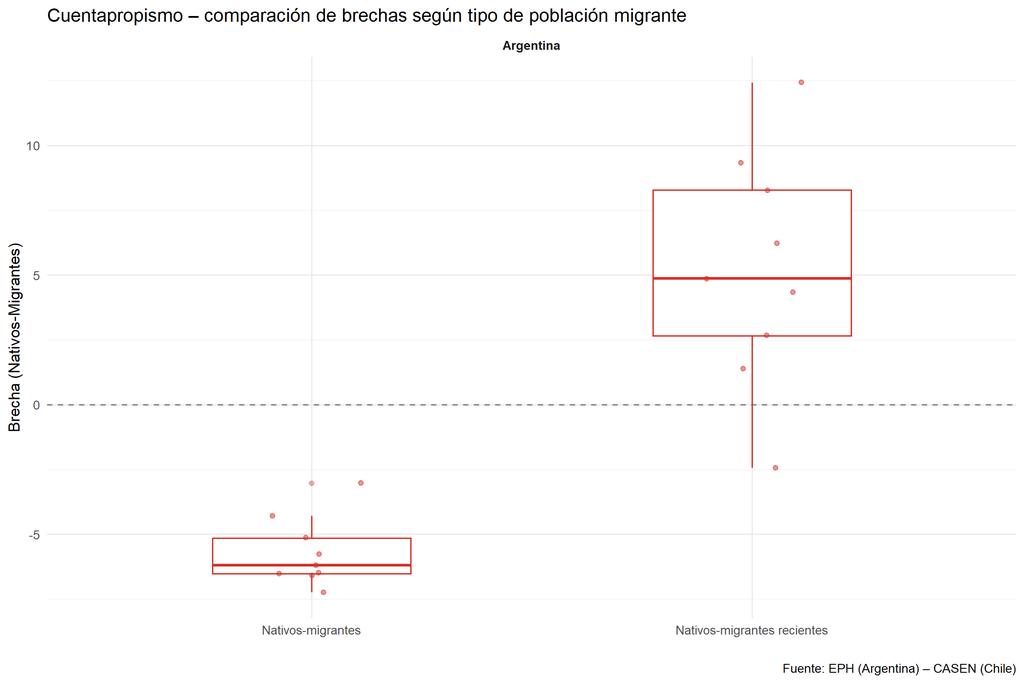

# (I6) Pobreza monetaria

## Datos completos

### Argentina

| pais | fuente | anio | indicador_clean | nativos | migrantes | migrantes_recientes | brecha_nat_mig | brecha_nat_rec |
| --- | --- | --- | --- | --- | --- | --- | --- | --- |
| Argentina | EPH | 2016 | Pobreza | 33.07 | 31.73 | 32.75 | 1.33 | 0.31 |
| Argentina | EPH | 2017 | Pobreza | 29.00 | 28.31 | 28.56 | 0.69 | 0.44 |
| Argentina | EPH | 2018 | Pobreza | 31.61 | 31.01 | 33.15 | 0.60 | -1.54 |
| Argentina | EPH | 2019 | Pobreza | 37.45 | 35.17 | 18.83 | 2.28 | 18.62 |
| Argentina | EPH | 2020 | Pobreza | 42.46 | 49.79 | 51.25 | -7.33 | -8.79 |
| Argentina | EPH | 2021 | Pobreza | 40.84 | 39.64 | 27.55 | 1.20 | 13.29 |
| Argentina | EPH | 2022 | Pobreza | 39.74 | 37.78 | 28.87 | 1.96 | 10.87 |
| Argentina | EPH | 2023 | Pobreza | 42.47 | 41.64 | 34.01 | 0.84 | 8.46 |
| Argentina | EPH | 2024 | Pobreza | 46.63 | 44.95 | 38.26 | 1.68 | 8.36 |

### Chile

| pais | fuente | anio | indicador_clean | nativos | migrantes | migrantes_recientes | brecha_nat_mig | brecha_nat_rec |
| --- | --- | --- | --- | --- | --- | --- | --- | --- |
| Chile | CASEN | 2015 | Pobreza | 11.72 | 9.53 | 9.65 | 2.19 | 2.07 |
| Chile | CASEN | 2017 | Pobreza | 8.48 | 11.20 | 11.30 | -2.71 | -2.82 |
| Chile | CASEN | 2022 | Pobreza | 6.08 | 11.31 | 11.25 | -5.23 | -5.17 |
| Chile | CASEN | 2024 | Pobreza | 16.70 | 24.48 | 30.96 | -7.78 | -14.26 |

## Datos por perìodo

Brecha = Nativos - Migrantes (puntos porcentuales). Chile: ENE prioritaria; CASEN si corresponde al indicador.

| Período | Argentina Nativos | Argentina Migrantes | Argentina Brecha | Chile Nativos | Chile Migrantes | Chile Brecha |
| --- | --- | --- | --- | --- | --- | --- |
| 2015-2016 | 33.1 | 31.7 | 1.3 | 11.7 | 9.5 | 2.2 |
| 2017-2019 | 32.7 | 31.5 | 1.2 | 8.5 | 11.2 | −2.7 |
| 2020-2022 | 41.0 | 42.4 | −1.4 | 6.1 | 11.3 | −5.2 |
| 2023-2024 | 44.5 | 43.3 | 1.3 | 16.7 | 24.5 | −7.8 |

## Serie temporal

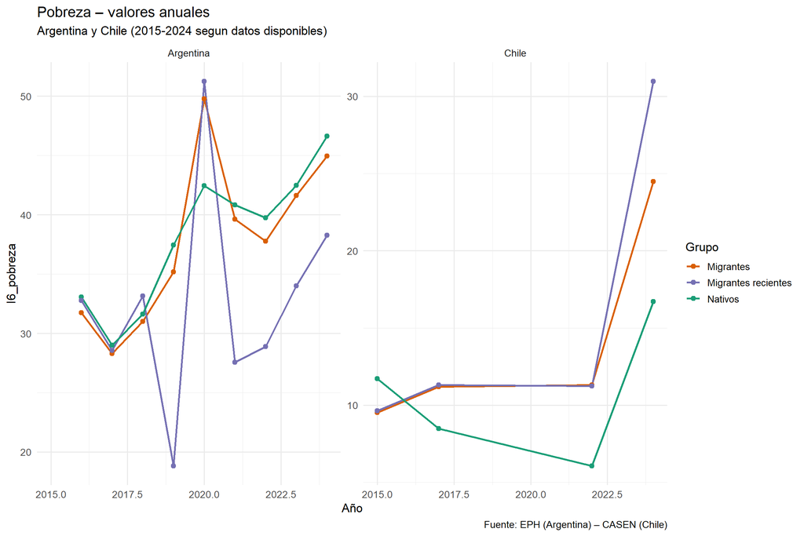

## Brechas nativos - migrantes

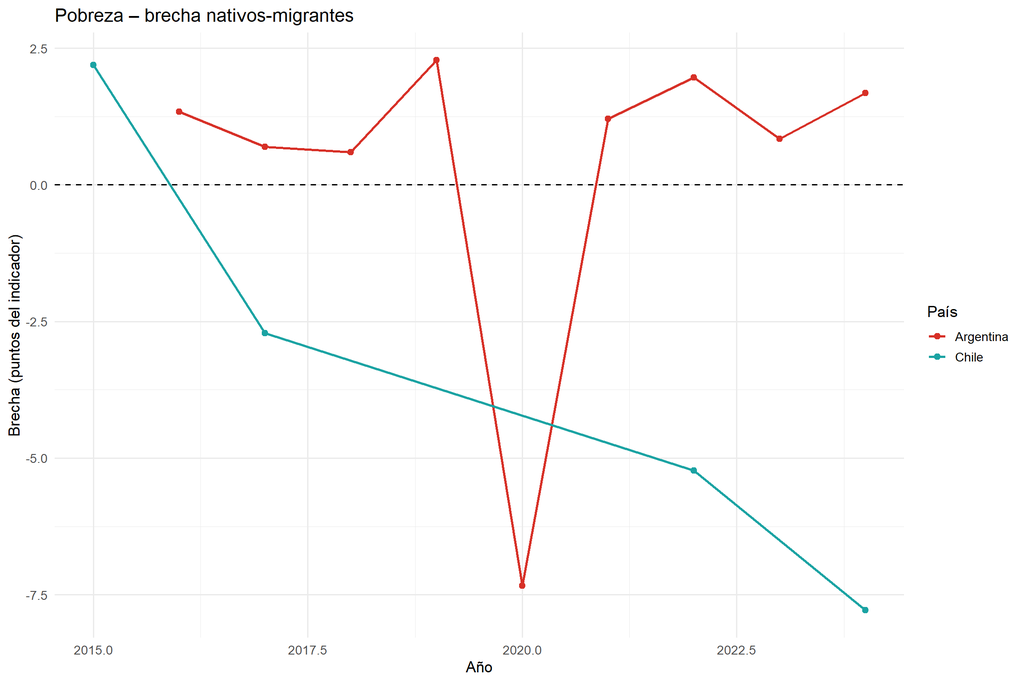

##Brechas - incorporación migración reciente

EN CHile la fuente ENE no contempla esta información.

Es más relevante el análisis para Argentina porque permite mayor comparibilidad con Chile donde la migración está más concentrada en migración reciente

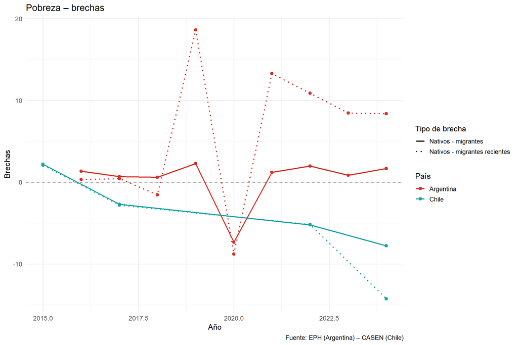

## Brechas estandarizadas

Bajo esta transformación, las brechas estandarizadas se interpretan como desviaciones respecto del promedio del indicador:

```
Z_(i,c,t)>0: integración relativa de la población migrante superior al promedio del indicador

Z_(i,c,t)<0: integración relativa inferior al promedio

Z_(i,c,t)=0: brecha equivalente al promedio del indicador
```

La magnitud de Z_(i,c,t)indica cuántos desvíos estándar se encuentra la brecha observada respecto de la media.

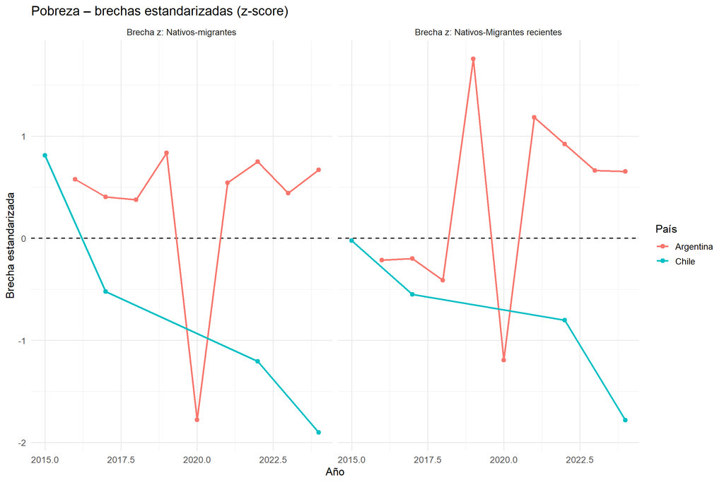

## Distribución de brechas

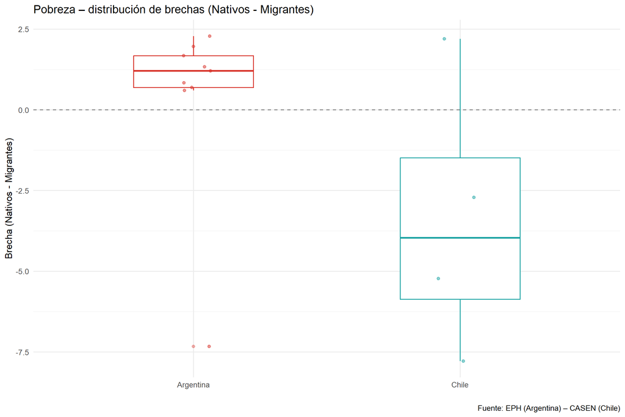

## Distribucion de brechas - grafico 2

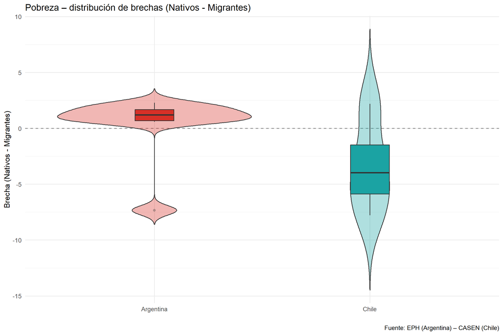

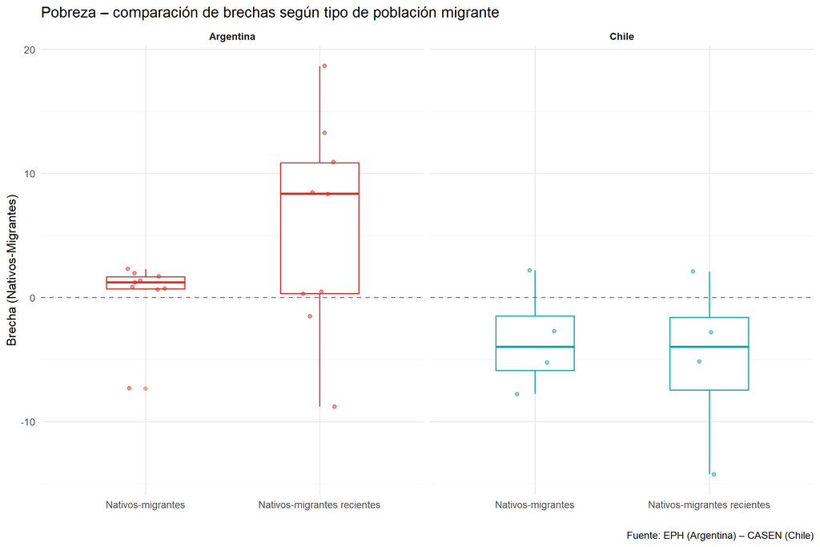

# (I7) Pobreza extrema / Indigencia

## Datos completos

### Argentina

| pais | fuente | anio | indicador_clean | nativos | migrantes | migrantes_recientes | brecha_nat_mig | brecha_nat_rec |
| --- | --- | --- | --- | --- | --- | --- | --- | --- |
| Argentina | EPH | 2016 | Pobreza Extrema | 6.85 | 8.65 | 5.89 | -1.80 | 0.96 |
| Argentina | EPH | 2017 | Pobreza Extrema | 6.17 | 7.22 | 4.80 | -1.06 | 1.36 |
| Argentina | EPH | 2018 | Pobreza Extrema | 6.37 | 8.18 | 10.02 | -1.81 | -3.65 |
| Argentina | EPH | 2019 | Pobreza Extrema | 8.66 | 9.38 | 7.45 | -0.73 | 1.21 |
| Argentina | EPH | 2020 | Pobreza Extrema | 11.07 | 16.00 | 19.99 | -4.93 | -8.92 |
| Argentina | EPH | 2021 | Pobreza Extrema | 10.55 | 11.22 | 6.52 | -0.67 | 4.03 |
| Argentina | EPH | 2022 | Pobreza Extrema | 8.93 | 8.88 | 3.02 | 0.05 | 5.92 |
| Argentina | EPH | 2023 | Pobreza Extrema | 11.53 | 12.15 | 10.86 | -0.62 | 0.67 |
| Argentina | EPH | 2024 | Pobreza Extrema | 14.19 | 13.79 | 10.52 | 0.40 | 3.66 |

### Chile

| pais | fuente | anio | indicador_clean | nativos | migrantes | migrantes_recientes | brecha_nat_mig | brecha_nat_rec |
| --- | --- | --- | --- | --- | --- | --- | --- | --- |
| Chile | CASEN | 2015 | Pobreza Extrema | 3.52 | 4.19 | 4.26 | -0.67 | -0.74 |
| Chile | CASEN | 2017 | Pobreza Extrema | 2.24 | 4.37 | 4.45 | -2.14 | -2.21 |
| Chile | CASEN | 2022 | Pobreza Extrema | 1.83 | 3.89 | 3.89 | -2.05 | -2.05 |
| Chile | CASEN | 2024 | Pobreza Extrema | 6.58 | 10.37 | 14.26 | -3.79 | -7.68 |

## Datos por perìodo

Brecha = Nativos - Migrantes (puntos porcentuales). Chile: ENE prioritaria; CASEN si corresponde al indicador.

| Período | Argentina Nativos | Argentina Migrantes | Argentina Brecha | Chile Nativos | Chile Migrantes | Chile Brecha |
| --- | --- | --- | --- | --- | --- | --- |
| 2015-2016 | 6.8 | 8.6 | −1.8 | 3.5 | 4.2 | −0.7 |
| 2017-2019 | 7.1 | 8.3 | −1.2 | 2.2 | 4.4 | −2.1 |
| 2020-2022 | 10.2 | 12.0 | −1.8 | 1.8 | 3.9 | −2.1 |
| 2023-2024 | 12.9 | 13.0 | −0.1 | 6.6 | 10.4 | −3.8 |

## Serie temporal

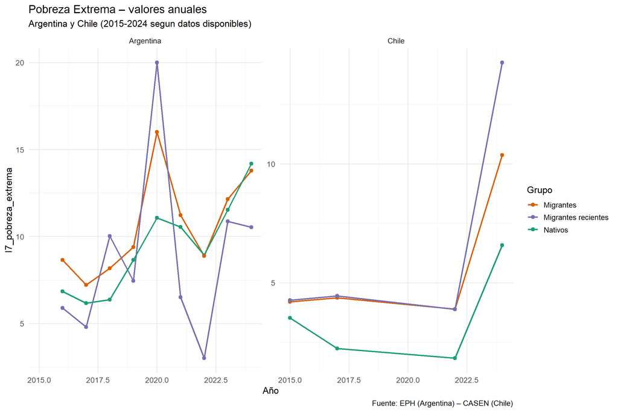

## Brechas nativos - migrantes

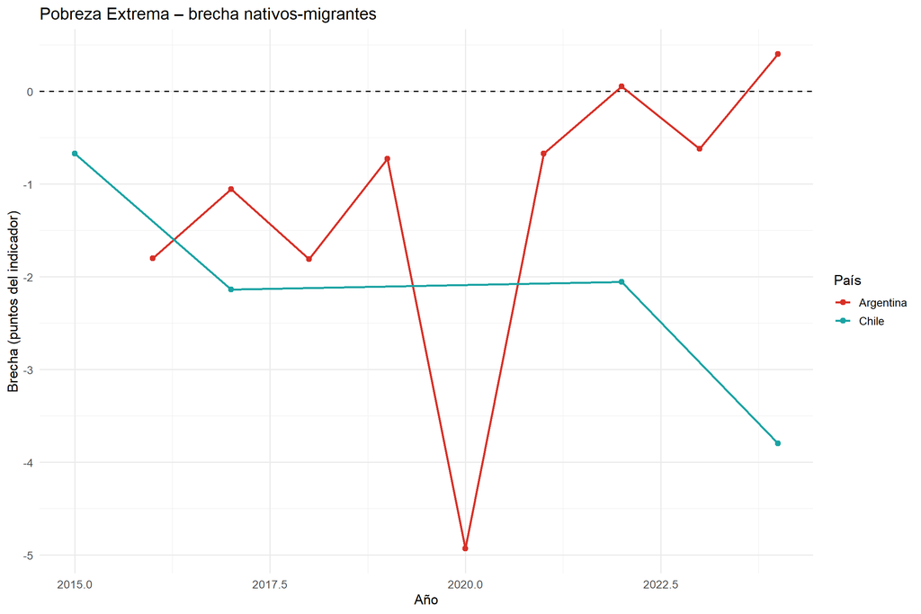

##Brechas - incorporación migración reciente

EN CHile la fuente ENE no contempla esta información.

Es más relevante el análisis para Argentina porque permite mayor comparibilidad con Chile donde la migración está más concentrada en migración reciente

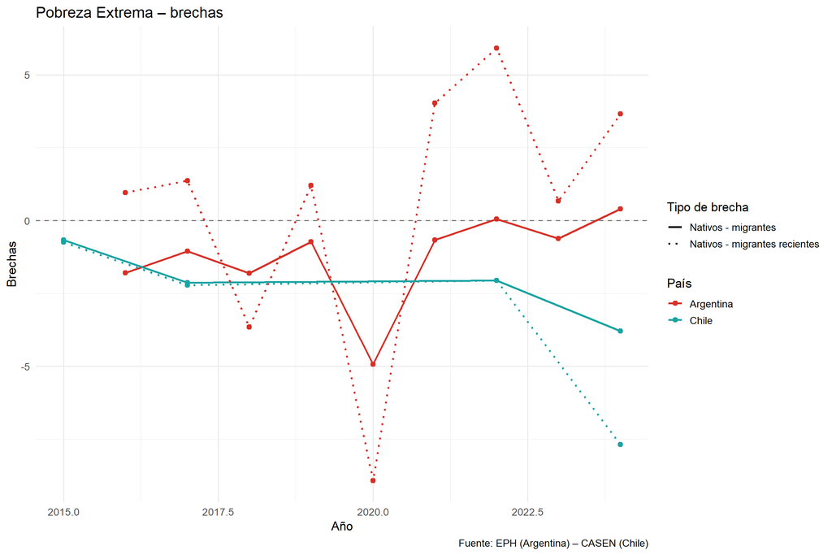

## Brechas estandarizadas

Bajo esta transformación, las brechas estandarizadas se interpretan como desviaciones respecto del promedio del indicador:

```
Z_(i,c,t)>0: integración relativa de la población migrante superior al promedio del indicador

Z_(i,c,t)<0: integración relativa inferior al promedio

Z_(i,c,t)=0: brecha equivalente al promedio del indicador
```

La magnitud de Z_(i,c,t)indica cuántos desvíos estándar se encuentra la brecha observada respecto de la media.

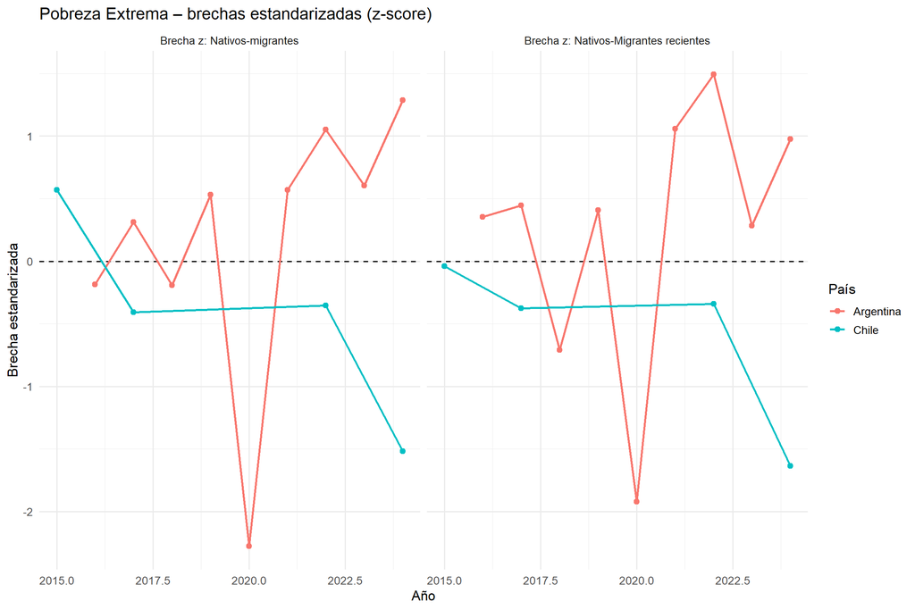

## Distribución de brechas

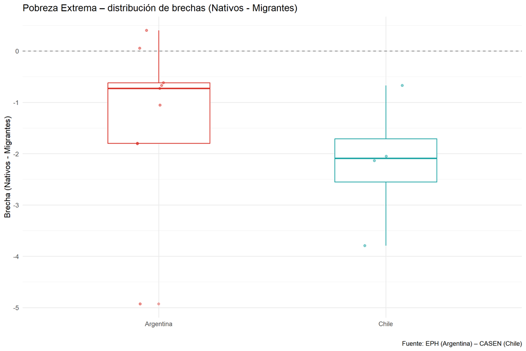

## Distribucion de brechas - grafico 2

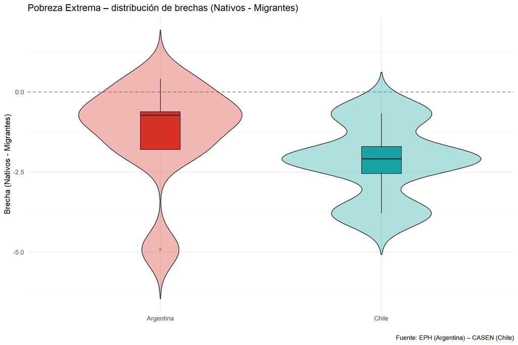

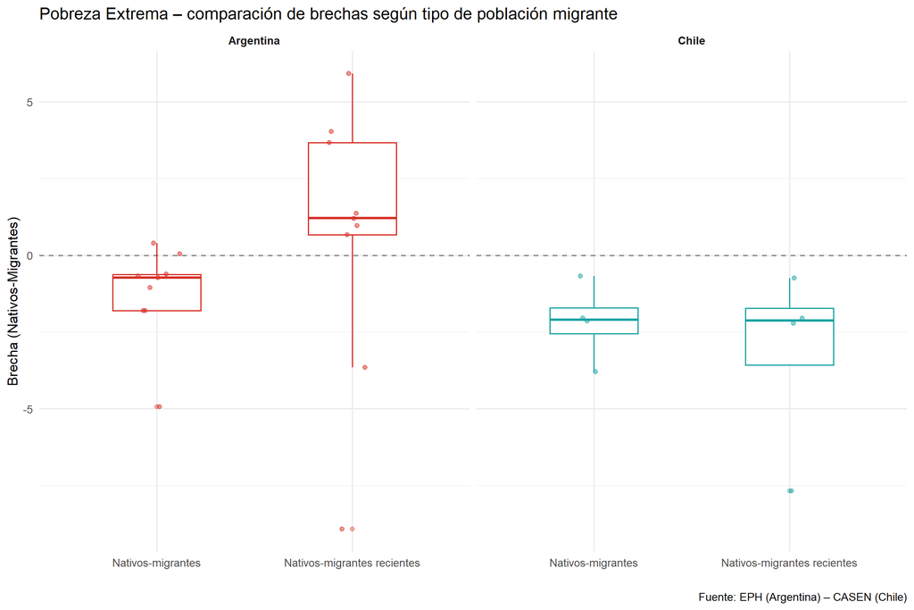

# (I8) Asistencia escolar obligatoria (6 a 17 años) - primaria y secundaria obligatoria

## Datos completos

### Argentina

| pais | fuente | anio | indicador_clean | nativos | migrantes | migrantes_recientes | brecha_nat_mig | brecha_nat_rec |
| --- | --- | --- | --- | --- | --- | --- | --- | --- |
| Argentina | EPH | 2016 | Asistencia Escolar 6 17 | 95.88 | 97.40 | 100.00 | -1.52 | -4.12 |
| Argentina | EPH | 2017 | Asistencia Escolar 6 17 | 96.60 | 94.79 | 90.56 | 1.81 | 6.04 |
| Argentina | EPH | 2018 | Asistencia Escolar 6 17 | 96.93 | 94.99 | 93.34 | 1.94 | 3.60 |
| Argentina | EPH | 2019 | Asistencia Escolar 6 17 | 97.08 | 95.02 | 91.10 | 2.06 | 5.98 |
| Argentina | EPH | 2020 | Asistencia Escolar 6 17 | 97.63 | 91.03 | 87.55 | 6.60 | 10.08 |
| Argentina | EPH | 2021 | Asistencia Escolar 6 17 | 98.02 | 93.05 | 80.79 | 4.97 | 17.23 |
| Argentina | EPH | 2022 | Asistencia Escolar 6 17 | 98.15 | 94.35 | 87.35 | 3.80 | 10.79 |
| Argentina | EPH | 2023 | Asistencia Escolar 6 17 | 98.22 | 94.89 | 97.56 | 3.33 | 0.66 |
| Argentina | EPH | 2024 | Asistencia Escolar 6 17 | 97.87 | 97.67 | 100.00 | 0.21 | -2.13 |

### Chile

| pais | fuente | anio | indicador_clean | nativos | migrantes | migrantes_recientes | brecha_nat_mig | brecha_nat_rec |
| --- | --- | --- | --- | --- | --- | --- | --- | --- |
| Chile | CASEN | 2015 | Asistencia Escolar 6 17 | 98.43 | 93.80 | 93.44 | 4.63 | 4.99 |
| Chile | CASEN | 2017 | Asistencia Escolar 6 17 | 98.67 | 81.38 | 80.66 | 17.29 | 18.02 |
| Chile | CASEN | 2022 | Asistencia Escolar 6 17 | 99.18 | 94.44 | 94.39 | 4.74 | 4.79 |
| Chile | CASEN | 2024 | Asistencia Escolar 6 17 | 98.81 | 95.62 | 92.87 | 3.19 | 5.94 |

## Datos por perìodo

Brecha = Nativos - Migrantes (puntos porcentuales). Chile: ENE prioritaria; CASEN si corresponde al indicador.

| Período | Argentina Nativos | Argentina Migrantes | Argentina Brecha | Chile Nativos | Chile Migrantes | Chile Brecha |
| --- | --- | --- | --- | --- | --- | --- |
| 2015-2016 | 95.9 | 97.4 | −1.5 | 98.4 | 93.8 | 4.6 |
| 2017-2019 | 96.9 | 94.9 | 1.9 | 98.7 | 81.4 | 17.3 |
| 2020-2022 | 97.9 | 92.8 | 5.1 | 99.2 | 94.4 | 4.7 |
| 2023-2024 | 98.0 | 96.3 | 1.8 | 98.8 | 95.6 | 3.2 |

## Serie temporal

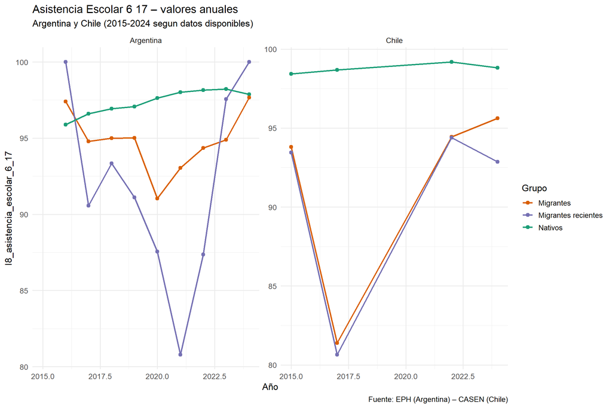

## Brechas nativos - migrantes

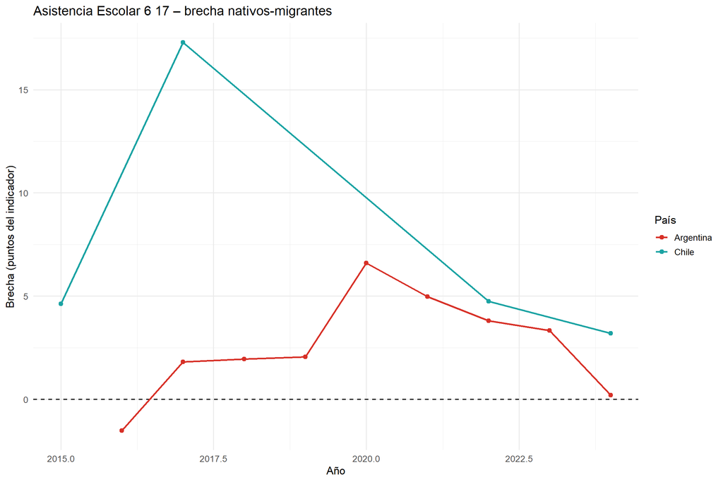

##Brechas - incorporación migración reciente

EN CHile la fuente ENE no contempla esta información.

Es más relevante el análisis para Argentina porque permite mayor comparibilidad con Chile donde la migración está más concentrada en migración reciente

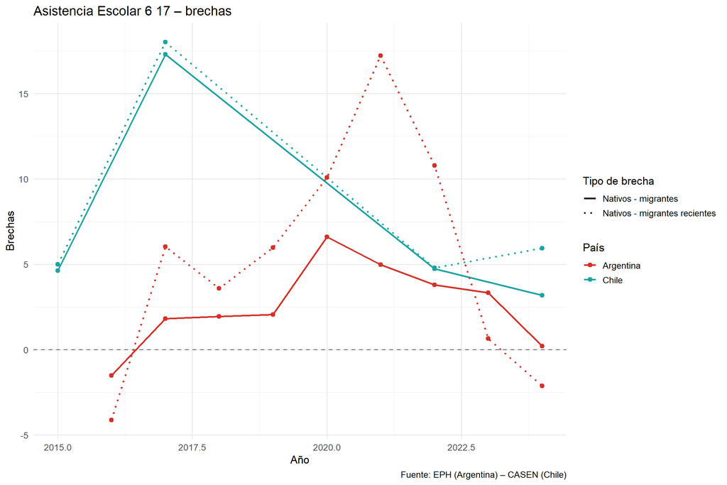

## Brechas estandarizadas

Bajo esta transformación, las brechas estandarizadas se interpretan como desviaciones respecto del promedio del indicador:

[output not shown]

La magnitud de Z_(i,c,t)indica cuántos desvíos estándar se encuentra la brecha observada respecto de la media.

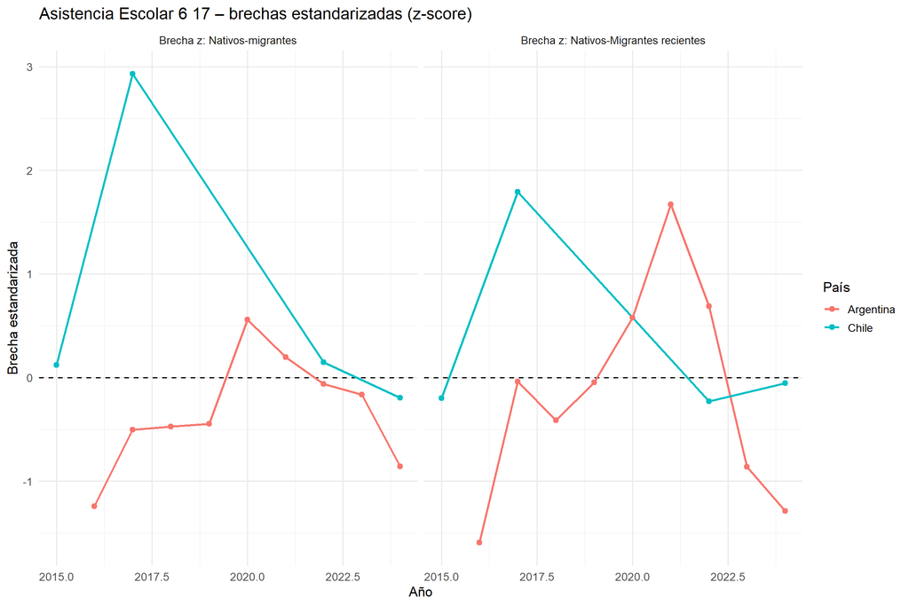

## Distribución de brechas

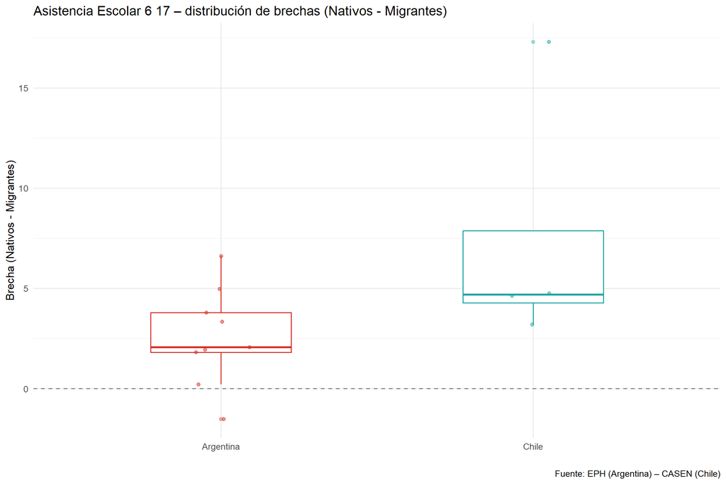

## Distribucion de brechas - grafico 2

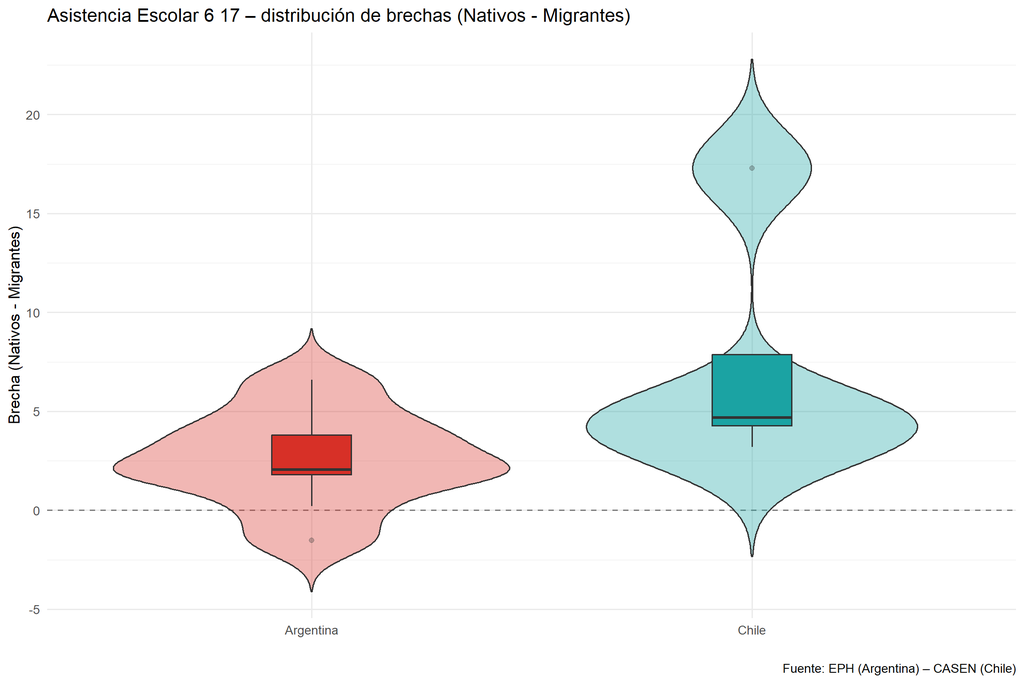

## distribucion de brechas migracion general y reciente en Argentina

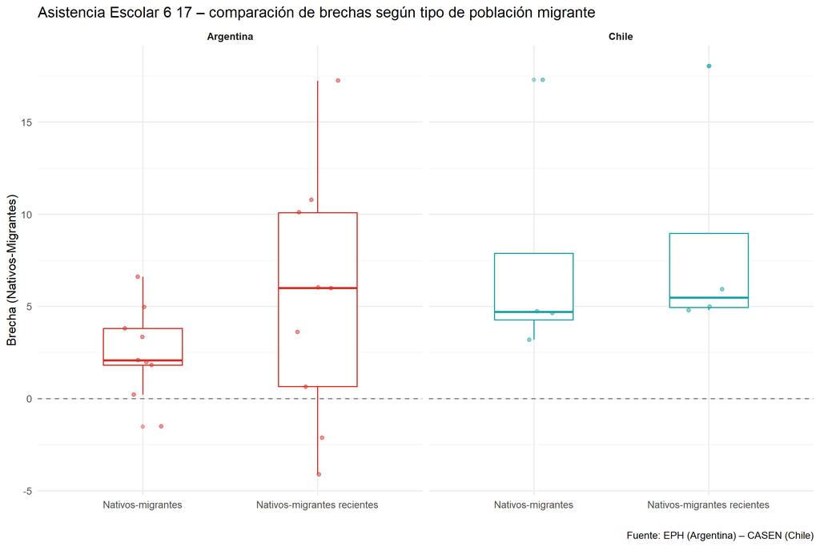

# (I9) Asistencia a estudios superiroes (18 a 29 años) tercierarios, universitarios y postgrados

## Datos completos

### Argentina

| pais | fuente | anio | indicador_clean | nativos | migrantes | migrantes_recientes | brecha_nat_mig | brecha_nat_rec |
| --- | --- | --- | --- | --- | --- | --- | --- | --- |
| Argentina | EPH | 2016 | Asistencia Superior 18 29 | 27.50 | 16.81 | 22.02 | 10.69 | 5.49 |
| Argentina | EPH | 2017 | Asistencia Superior 18 29 | 28.16 | 23.49 | 29.99 | 4.67 | -1.83 |
| Argentina | EPH | 2018 | Asistencia Superior 18 29 | 29.25 | 22.91 | 37.70 | 6.34 | -8.45 |
| Argentina | EPH | 2019 | Asistencia Superior 18 29 | 29.06 | 23.99 | 29.26 | 5.07 | -0.19 |
| Argentina | EPH | 2020 | Asistencia Superior 18 29 | 29.27 | 22.49 | 36.72 | 6.78 | -7.45 |
| Argentina | EPH | 2021 | Asistencia Superior 18 29 | 31.44 | 32.30 | 29.42 | -0.87 | 2.01 |
| Argentina | EPH | 2022 | Asistencia Superior 18 29 | 29.86 | 29.64 | 45.40 | 0.23 | -15.53 |
| Argentina | EPH | 2023 | Asistencia Superior 18 29 | 30.92 | 34.39 | 51.76 | -3.47 | -20.84 |
| Argentina | EPH | 2024 | Asistencia Superior 18 29 | 30.23 | 37.00 | 42.45 | -6.77 | -12.21 |

### Chile

| pais | fuente | anio | indicador_clean | nativos | migrantes | migrantes_recientes | brecha_nat_mig | brecha_nat_rec |
| --- | --- | --- | --- | --- | --- | --- | --- | --- |
| Chile | CASEN | 2015 | Asistencia Superior 18 29 | 30.47 | 9.97 | 8.91 | 20.49 | 21.55 |
| Chile | CASEN | 2017 | Asistencia Superior 18 29 | 29.99 | 7.05 | 6.94 | 22.94 | 23.05 |
| Chile | CASEN | 2022 | Asistencia Superior 18 29 | 32.55 | 7.72 | 7.64 | 24.83 | 24.91 |
| Chile | CASEN | 2024 | Asistencia Superior 18 29 | 33.01 | 9.16 | 3.65 | 23.84 | 29.35 |

## Datos por perìodo

Brecha = Nativos - Migrantes (puntos porcentuales). Chile: ENE prioritaria; CASEN si corresponde al indicador.

| Período | Argentina Nativos | Argentina Migrantes | Argentina Brecha | Chile Nativos | Chile Migrantes | Chile Brecha |
| --- | --- | --- | --- | --- | --- | --- |
| 2015-2016 | 27.5 | 16.8 | 10.7 | 30.5 | 10.0 | 20.5 |
| 2017-2019 | 28.8 | 23.5 | 5.4 | 30.0 | 7.0 | 22.9 |
| 2020-2022 | 30.2 | 28.1 | 2.1 | 32.5 | 7.7 | 24.8 |
| 2023-2024 | 30.6 | 35.7 | −5.1 | 33.0 | 9.2 | 23.8 |

## Serie temporal

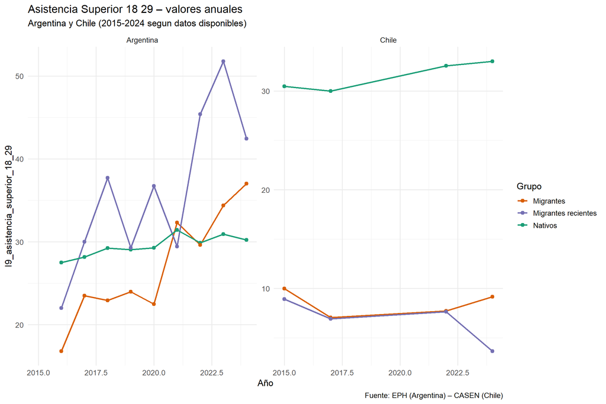

## Brechas nativos - migrantes

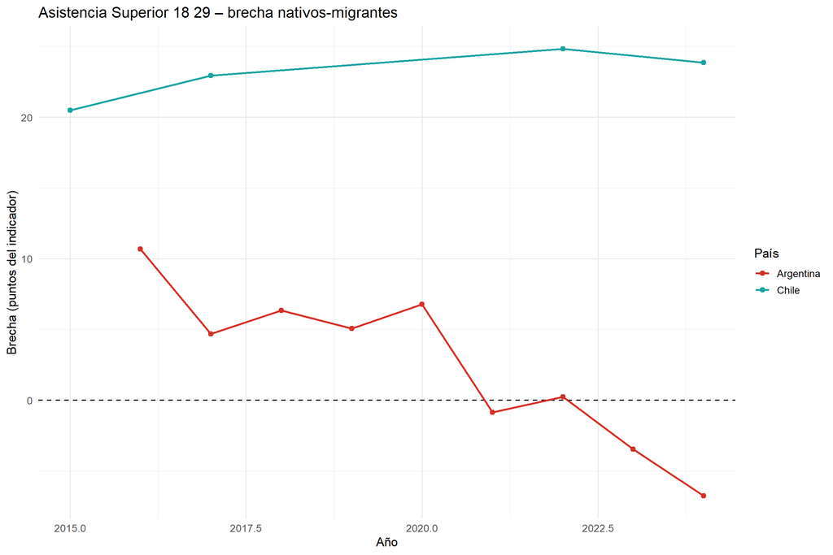

##Brechas - incorporación migración reciente

EN CHile la fuente ENE no contempla esta información.

Es más relevante el análisis para Argentina porque permite mayor comparibilidad con Chile donde la migración está más concentrada en migración reciente

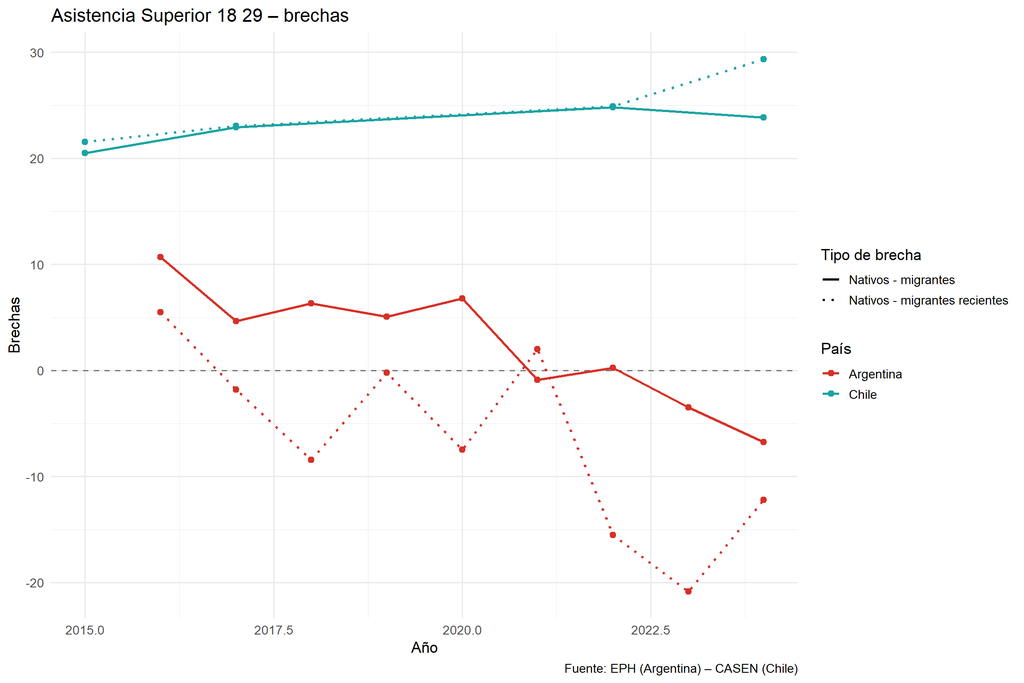

## Brechas estandarizadas

Bajo esta transformación, las brechas estandarizadas se interpretan como desviaciones respecto del promedio del indicador:

[output not shown]

La magnitud de Z_(i,c,t)indica cuántos desvíos estándar se encuentra la brecha observada respecto de la media.

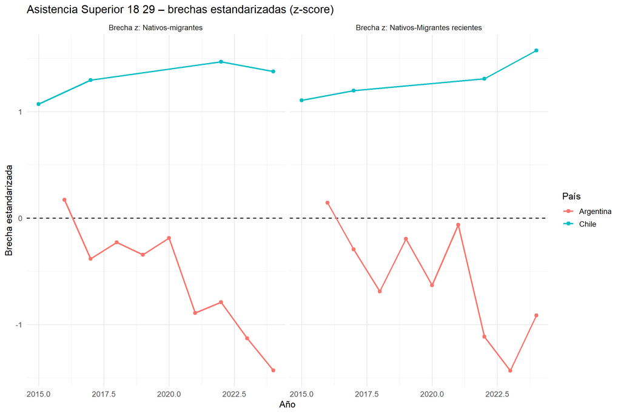

## Distribución de brechas

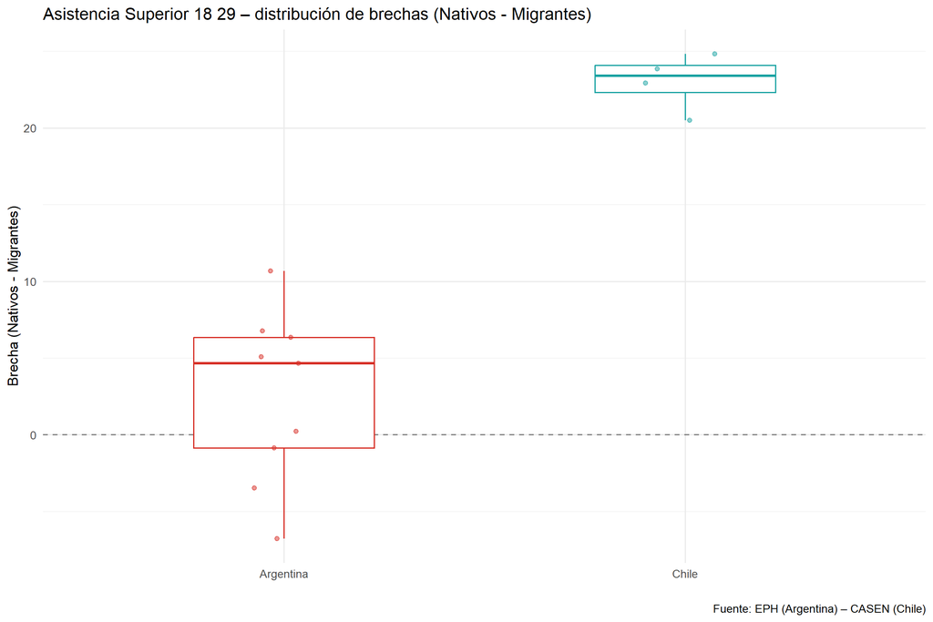

## Distribucion de brechas - grafico 2

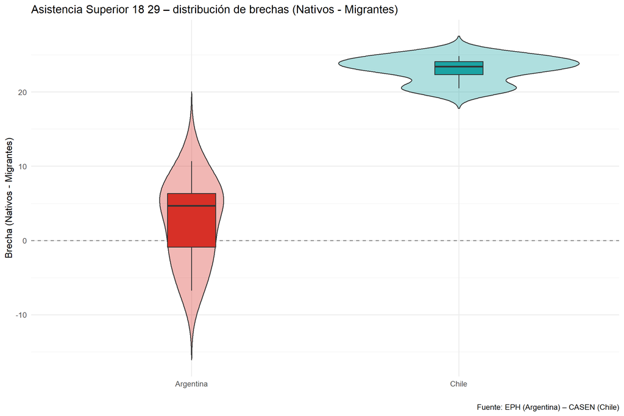

## distribucion de brechas migracion general y reciente en Argentina

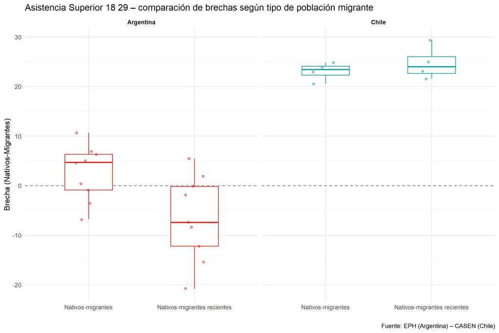

# (I10) Dependencia/acceso al sistema de salud publico

## Datos completos

### Argentina

| pais | fuente | anio | indicador_clean | nativos | migrantes | migrantes_recientes | brecha_nat_mig | brecha_nat_rec |
| --- | --- | --- | --- | --- | --- | --- | --- | --- |
| Argentina | EPH | 2016 | I10 Sistema Salud Publico | 30.49 | 38.89 | 53.30 | -8.40 | -22.81 |
| Argentina | EPH | 2017 | I10 Sistema Salud Publico | 30.54 | 38.80 | 60.79 | -8.27 | -30.25 |
| Argentina | EPH | 2018 | I10 Sistema Salud Publico | 30.23 | 39.80 | 57.92 | -9.58 | -27.69 |
| Argentina | EPH | 2019 | I10 Sistema Salud Publico | 31.51 | 41.75 | 51.46 | -10.24 | -19.95 |
| Argentina | EPH | 2020 | I10 Sistema Salud Publico | 34.09 | 45.13 | 61.63 | -11.04 | -27.54 |
| Argentina | EPH | 2021 | I10 Sistema Salud Publico | 31.52 | 35.11 | 39.16 | -3.59 | -7.64 |
| Argentina | EPH | 2022 | I10 Sistema Salud Publico | 33.33 | 39.17 | 37.36 | -5.84 | -4.03 |
| Argentina | EPH | 2023 | I10 Sistema Salud Publico | 32.43 | 40.85 | 47.64 | -8.43 | -15.21 |
| Argentina | EPH | 2024 | I10 Sistema Salud Publico | 31.46 | 37.59 | 52.06 | -6.12 | -20.60 |

### Chile

| pais | fuente | anio | indicador_clean | nativos | migrantes | migrantes_recientes | brecha_nat_mig | brecha_nat_rec |
| --- | --- | --- | --- | --- | --- | --- | --- | --- |
| Chile | CASEN | 2015 | I10 Sistema Salud Publico | 53.99 | 37.35 | 37.93 | 16.64 | 16.05 |
| Chile | CASEN | 2017 | I10 Sistema Salud Publico | 55.10 | 40.21 | 40.30 | 14.89 | 14.79 |
| Chile | CASEN | 2022 | I10 Sistema Salud Publico | 54.79 | 46.50 | 46.42 | 8.29 | 8.38 |
| Chile | CASEN | 2024 | I10 Sistema Salud Publico | 57.74 | 58.44 | 64.10 | -0.70 | -6.37 |

## Datos por perìodo

Brecha = Nativos - Migrantes (puntos porcentuales). Chile: ENE prioritaria; CASEN si corresponde al indicador.

| Período | Argentina Nativos | Argentina Migrantes | Argentina Brecha | Chile Nativos | Chile Migrantes | Chile Brecha |
| --- | --- | --- | --- | --- | --- | --- |
| 2015-2016 | 30.5 | 38.9 | −8.4 | 54.0 | 37.4 | 16.6 |
| 2017-2019 | 30.8 | 40.1 | −9.4 | 55.1 | 40.2 | 14.9 |
| 2020-2022 | 33.0 | 39.8 | −6.8 | 54.8 | 46.5 | 8.3 |
| 2023-2024 | 31.9 | 39.2 | −7.3 | 57.7 | 58.4 | −0.7 |

## Serie temporal

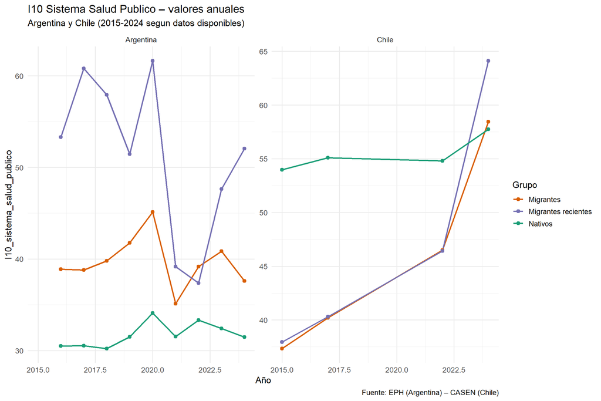

## Brechas nativos - migrantes

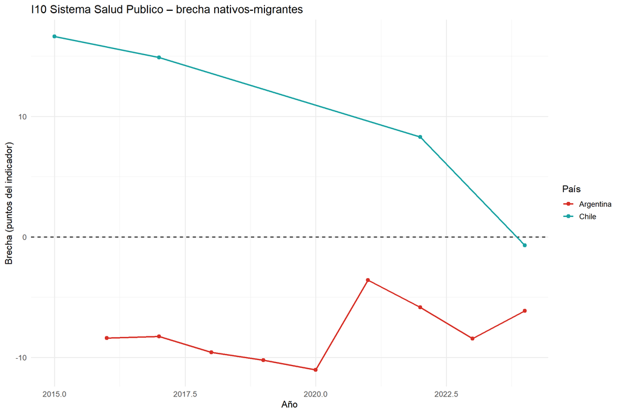

##Brechas - incorporación migración reciente

EN CHile la fuente ENE no contempla esta información.

Es más relevante el análisis para Argentina porque permite mayor comparibilidad con Chile donde la migración está más concentrada en migración reciente

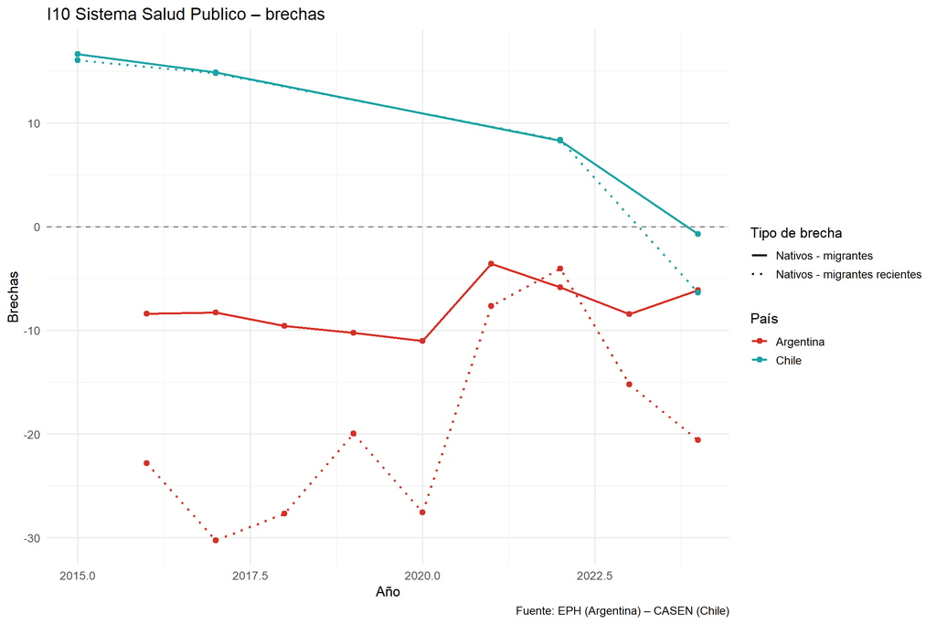

## Brechas estandarizadas

Bajo esta transformación, las brechas estandarizadas se interpretan como desviaciones respecto del promedio del indicador:

```
Z_(i,c,t)>0: integración relativa de la población migrante superior al promedio del indicador

Z_(i,c,t)<0: integración relativa inferior al promedio

Z_(i,c,t)=0: brecha equivalente al promedio del indicador
```

La magnitud de Z_(i,c,t)indica cuántos desvíos estándar se encuentra la brecha observada respecto de la media.

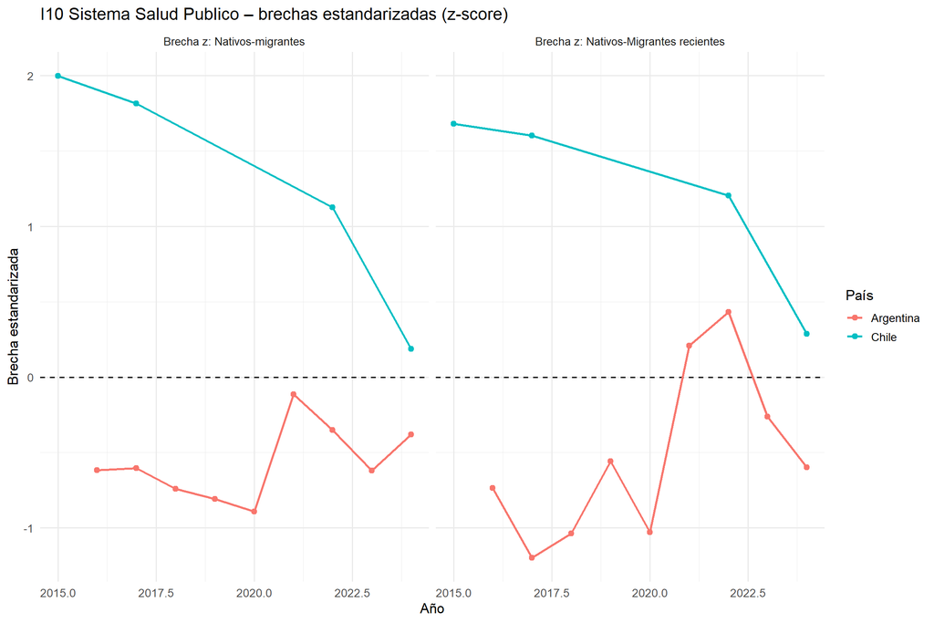

## Distribución de brechas

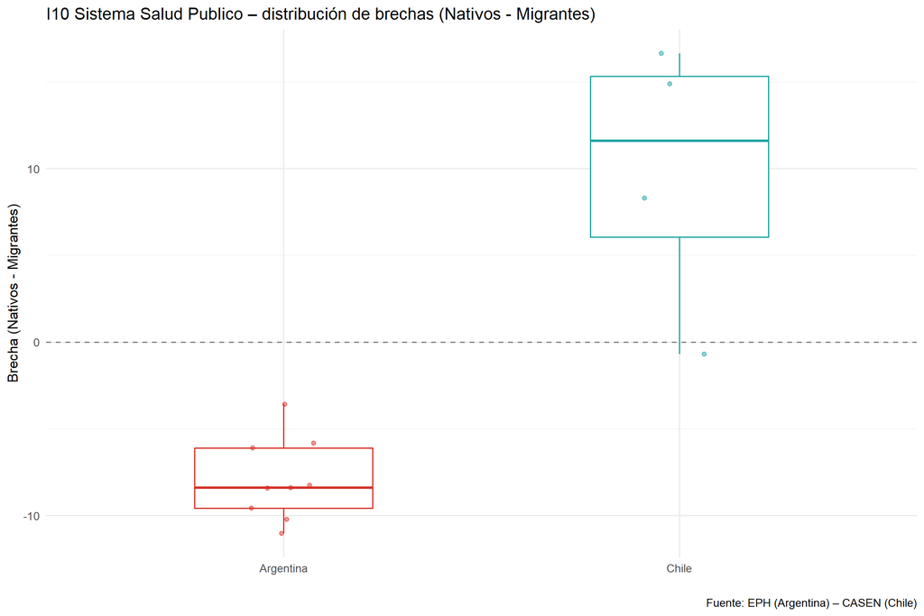

## Distribucion de brechas - grafico 2

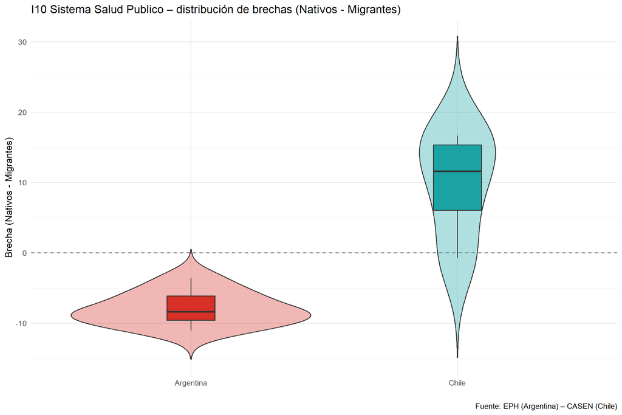

## distribucion de brechas migracion general y reciente en Argentina

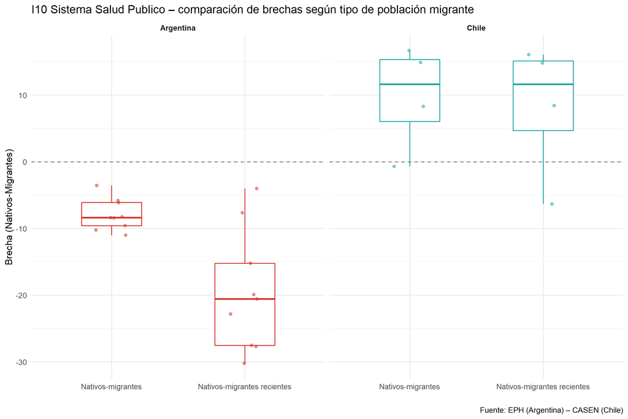

## guardar tabla indicadores por periodos

```
## ✓ Excel creado con 10 solapas
```

```
## ✓ Indicadores incluidos:
```

```
##    1 . I10_sistema_salud_publico
##    2 . I1_tasa_actividad
##    3 . I2_tasa_desempleo
##    4 . I3_informalidad_asalariada
##    5 . I4_informalidad_total
##    6 . I5_cuentapropismo
##    7 . I6_pobreza
##    8 . I7_pobreza_extrema
##    9 . I8_asistencia_escolar_6_17
##    10 . I9_asistencia_superior_18_29
```

```
## ✓ Archivo guardado en: /mnt/user-data/outputs/tablas_indicadores_por_periodo.xlsx
```